# Внешний курс 3 этап

## Разное

Отметил все команды, которые переводят права доступа файла `file.txt` из `r--r--r--` в `rwxrw-r--` (Рисунок 31).

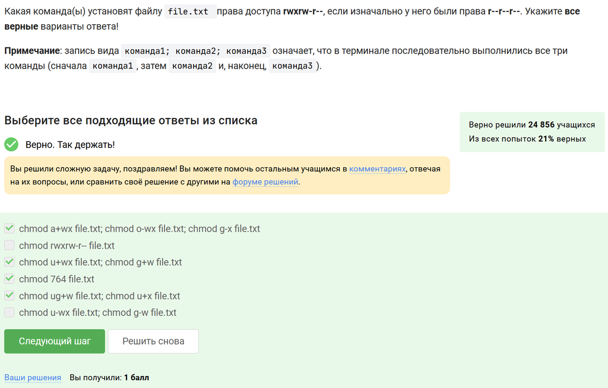

Рисунок 31: Изменение прав доступа файла через chmod

Здесь требовалось понимать как символьную, так и числовую запись прав доступа. Были отмечены корректные варианты как через последовательные символьные изменения, так и через числовой режим `764`.

Указал команды, после которых пользователь `user` из группы `group` сможет создавать файлы в директории `dir`, созданной через `sudo` (Рисунок 32).

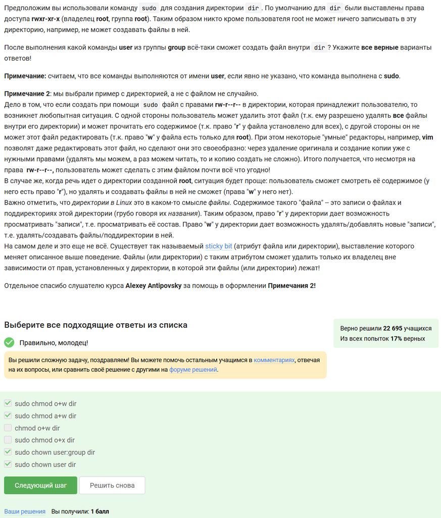

Рисунок 32: Права на директорию и возможность создавать файлы внутри неё

Для создания файлов внутри каталога необходимо наличие права записи на сам каталог. Поэтому корректными являются команды, которые либо выдают право записи другим пользователям, либо передают владение каталогом пользователю.

Отметил характеристики файла, которые можно посчитать при помощи команды `wc`: количество строк, слов и символов (Рисунок 33).

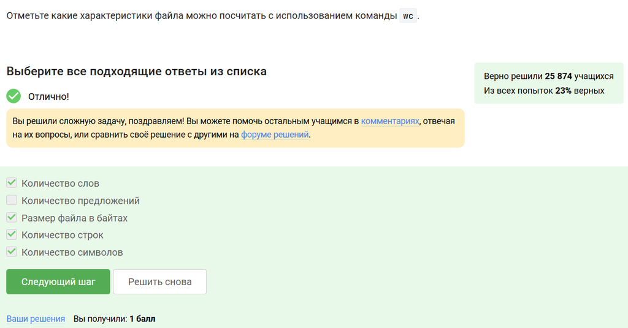

Рисунок 33: Использование команды wc

Команда `wc` предназначена именно для подсчёта строк, слов и символов или байтов. При этом количество предложений она напрямую не вычисляет.

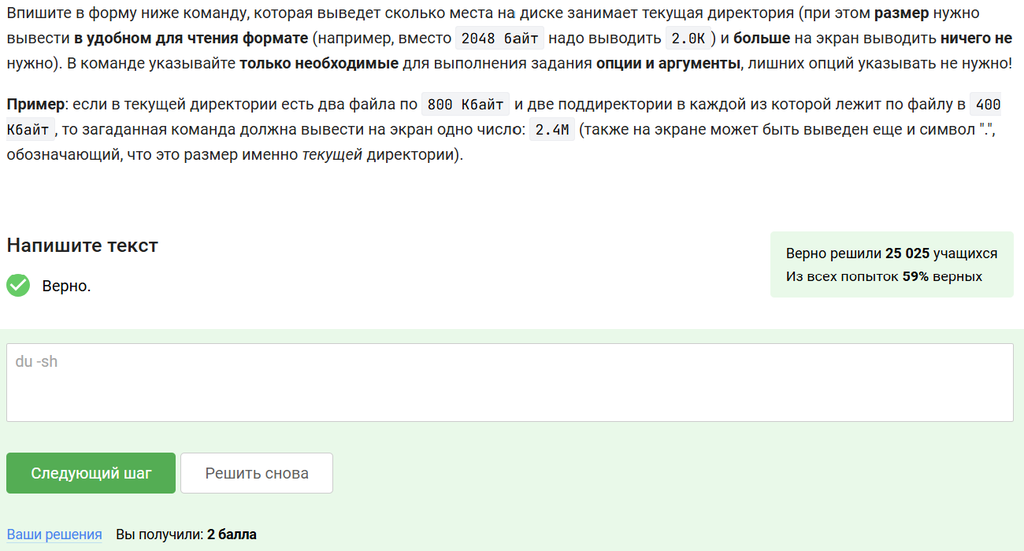

Рисунок 34: Определение размера текущей директории

Для решения использовалась команда `du` с опциями суммарного подсчёта и человекочитаемого формата. Она позволяет сразу получить итоговый размер каталога.

Вписал максимально короткую команду для создания трёх каталогов `dir1`, `dir2`, `dir3`: `mkdir dir{1..3}` (Рисунок 35).

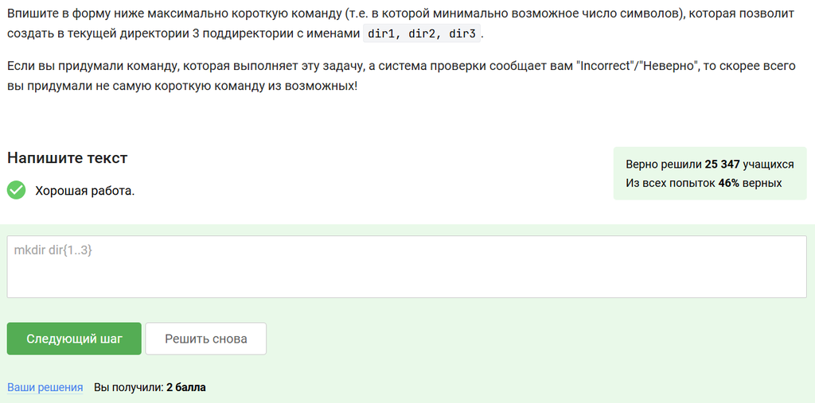

Рисунок 35: Создание нескольких директорий одной командой

В этом задании использовалось раскрытие фигурных скобок в оболочке `bash`, что позволяет кратко записывать последовательности имён файлов и каталогов.

# Выводы

В ходе выполнения третьего этапа внешнего курса были изучены и закреплены приёмы работы с редактором `vim`, написанием `bash`-скриптов, использованием позиционных параметров, условий, циклов, функций и рекурсии. Также были отработаны навыки поиска файлов и обработки текста командами `find`, `grep`, `sed`, основы построения графиков в `gnuplot`, а также управление правами доступа и использование утилит `chmod`, `wc`, `du` и `mkdir`. Полученные знания расширяют практические навыки работы в Linux и позволяют увереннее решать прикладные задачи автоматизации и обработки данных.